# Using the “forecastHybrid” package

## Forecasting

Now’s let’s forecast future values. The `forecast()` function produce an S3 class `forecast` object for the next 48 periods from the ensemble model.

```r
hForecast <- forecast(hm1, h = 48)
```

Now plot the forecast for the next 48 periods. The prediction intervals are preserved from the individual component models and currently use the most extreme value from an individual model, producing a conservative estimate for the ensemble’s performance.

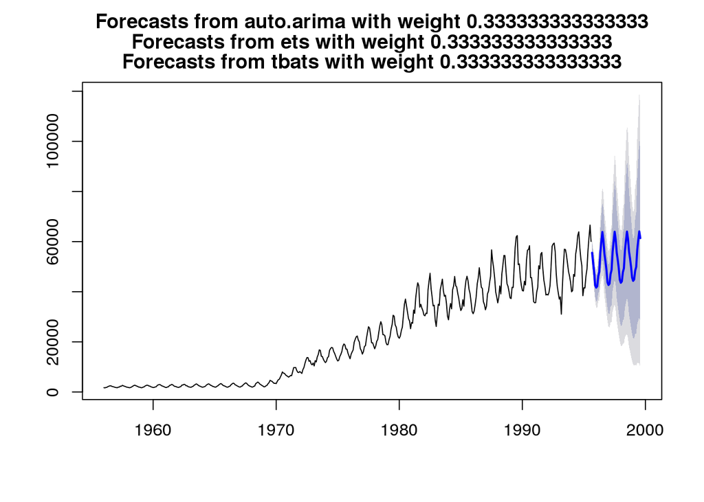

```r
plot(hForecast)
```

# Advanced usage

The package aims to make fitting ensembles easy and quick, but it still allows advanced tuning of all the parameters available in the “forecast” package. This is possible through usage of the `a.args`, `e.args`, `n.args`, `s.args`, and `t.args` lists. These optional list arguments may be applied to one, none, all, or any combination of the included individual component models. Consult the documentation in the “forecast” package for acceptable arguments to pass in the `auto.arima`, `ets`, `nnetar`, `stlm`, and `tbats` functions.

```r
hm2 <- hybridModel(y = gas, models = "aenst",
                   a.args = list(max.p = 12, max.q = 12, approximation = FALSE),
                   n.args = list(repeats = 50),
                   s.args = list(robust = TRUE),
                   t.args = list(use.arma.errors = FALSE))
```

Since the `lambda` argument is shared between all the models in the “forecast” framework, it is included as a special paramemeter that can be used to set the Box-Cox transform in all models instead of settings this individually. For example,

```r
hm3 <- hybridModel(y = wineind, models = "ae", lambda = 0.15)
hm3$auto.arima$lambda
```

```
## [1] 0.15
```

```r
hm3$ets$lambda
```

```
## [1] 0.15
```

Users can still apply the `lambda` argument through the tuning lists, but in this case the list-supplied argument overwrites the default used across all models. Compare the following two results.

```r
hm4 <- hybridModel(y = wineind, models = "aens", lambda = 0.2,
                   a.args = list(lambda = 0.5),
                   n.args = list(lambda = 0.6))
hm4$auto.arima$lambda
```

```
## [1] 0.5
```

```r
hm4$ets$lambda
```

```
## [1] 0.2
```

```r
hm4$nnetar$lambda
```

```
## [1] 0.6
```

```r
hm4$stlm$lambda
```

```
## [1] 0.2
```

Covariates can also be supplied to `auto.arima` and `nnetar` models as is done in the “forecast” package. To do this, utilize the `a.args` and `n.args` lists. Unlike the usage in the “forecast” package, the `xreg` argument should be passed as a dataframe, not a matrix. If a `xreg` is used in training, it must also be supplied to the `forecast()` fucntion in the `xreg` argument. Note that if the number of rows in the `xreg` to be used for the forecast does not match the supplied `h` forecast horizon, the function will overwrite `h` with the number of rows in `xreg` and issue a warning.

```r
# Use the beaver1 dataset with the variable "activ" as a covariate and "temp" as the timeseries
# Divice this into a train and test set
trainSet <- beaver1[1:100, ]
testSet <- beaver1[-(1:100), ]
trainXreg <- data.frame(trainSet$activ)
testXreg <- data.frame(testSet$activ)

# Create the model
beaverhm <- hybridModel(trainSet$temp,
                        models = "aent",
                        a.args = list(xreg = trainXreg),
                        n.args = list(xreg = trainXreg))
# Forecast future values
beaverfc <- forecast(beaverhm, xreg = testXreg)
```

```
## Warning in forecast.hybridModel(beaverhm, xreg = testXreg): The number of
## rows in xreg should match h. Setting h to nrow(xreg).
```

```r
# View the accuracy of the model
accuracy(beaverfc, testSet$temp)
```

```
##                       ME       RMSE        MAE         MPE      MAPE
## Training set 0.003342508 0.08762322 0.05927477 0.008756128 0.1606506
## Test set     0.085182320 0.11462422 0.09367066 0.230488076 0.2536171
##                   MASE       ACF1
## Training set 0.8986528 0.01650453
## Test set     1.4201218         NA
```